# Practical Machine Learning Project

Claudio Seidi Takamiya

15 de fevereiro de 2015

# Introduction

The project is based on research of Human Activity Recognition. The Weight Lifting Exercises dataset is provided by Groupware@LES. The objective of this project is identify “how well” an activity was performed. More information is available from the website http://groupware.les.inf.puc-rio.br/har.

# Exploratory Analysis

The number of features is quite large and analyze them one by time needs a lot of work.

```r
dim(dataset)
```

```
## [1] 19622   159
```

Many of variables are missing data and an imputation strategy doesn’t justify since their values are very sparse. The reason of this is most of them are summarization of other variables.

```r
head(dataset[, 11:17])
```

```
##   kurtosis_roll_belt kurtosis_picth_belt kurtosis_yaw_belt
## 1
## 2
## 3
## 4
## 5
## 6
##   skewness_roll_belt skewness_roll_belt.1 skewness_yaw_belt max_roll_belt
## 1                                                                      NA
## 2                                                                      NA
## 3                                                                      NA
## 4                                                                      NA
## 5                                                                      NA
## 6                                                                      NA
```

# Fitting model

Even ignoring 106 variables a lot of them still remaining. Therefore the Random Forests algorithm was chosen to fit a classifier model.

## Partitioning data set into training and testing sets.

```r
inTrain <- createDataPartition(y=training$classe, p=0.6, list=FALSE)
testing <- training[-inTrain, ]
training <-training[inTrain, ]
```

## Cross-validation for feature selection.

The following code shows the cross-validated prediction performance of models with sequentially reduced number of predictors. The plot shows the cross-validation error by number of variables used.

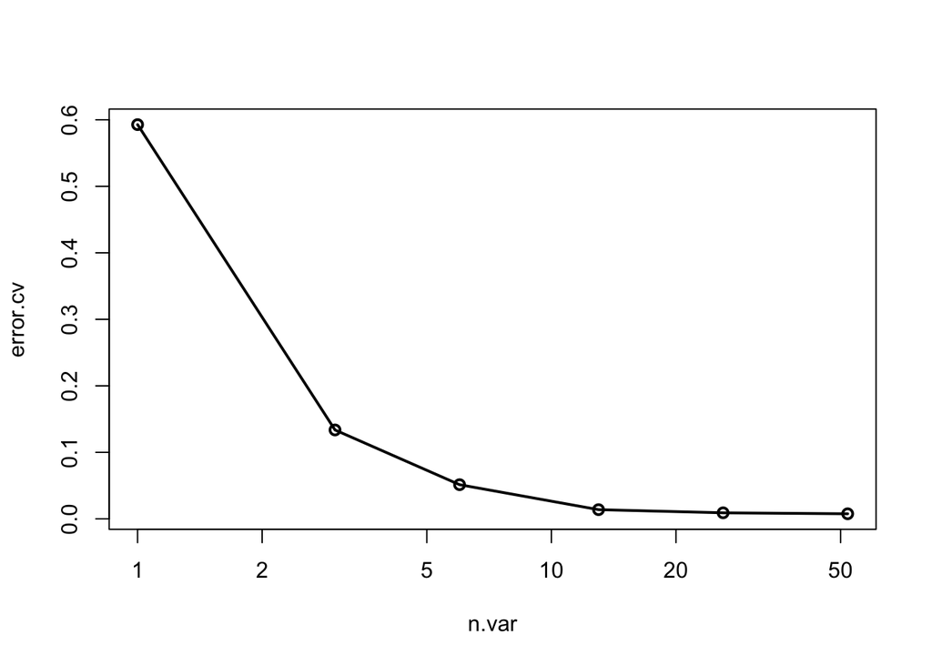

```r
result <- rfcv(training[, setdiff(names(training), "classe")], training$classe)
with(result, plot(n.var, error.cv, log="x",  type="o", lwd=2))
```

The number of 52 variables were returned as result of rfcv. This is the result with smaller error.

```r
result$error.cv
```

```
##       52       26       13        6        3        1
## 0.007643 0.009086 0.013842 0.051376 0.133662 0.592731
```

The number returned by rfcv function is used in the function randomForest as parameter mtry. This parameters specifies the number of variables randomly sampled as candidates at each split.

```r
modFit <- randomForest (x=training[, setdiff(names(training), "classe")],
                              y=training[, "classe"],
                              ntree=400,
                              mtry=result$n.var[which.min(result$error.cv)],
                              proximity=TRUE)

tab <- table(training$classe, predict(modFit))
class.error <- 1 - diag(tab) / apply(tab, 1, function(x) sum(x))
tab <- cbind(tab, class.error)
tab
```

```
##      A    B    C    D    E class.error
## A 3332    9    5    1    1    0.004779
## B   30 2214   27    5    3    0.028521
## C    4   22 2012   15    1    0.020448
## D    3    8   38 1876    5    0.027979
## E    0    3    8   10 2144    0.009700
```

```r
importance(modFit)
```

```
##                      MeanDecreaseGini
## roll_belt                     1456.03
## pitch_belt                     514.07
## yaw_belt                       682.72
## total_accel_belt                16.23
## gyros_belt_x                    25.21
## gyros_belt_y                    19.86
## gyros_belt_z                   156.38
## accel_belt_x                    28.62
## accel_belt_y                    14.74
## accel_belt_z                    67.83
## magnet_belt_x                  157.84
## magnet_belt_y                  104.96
## magnet_belt_z                  248.89
## roll_arm                        62.83
## pitch_arm                       46.61
## yaw_arm                        180.90
## total_accel_arm                 27.85
## gyros_arm_x                     43.17
## gyros_arm_y                     86.41
## gyros_arm_z                     15.91
## accel_arm_x                     73.04
## accel_arm_y                     42.71
## accel_arm_z                     39.67
## magnet_arm_x                    34.49
## magnet_arm_y                    98.46
## magnet_arm_z                    66.83
## roll_dumbbell                  170.09
## pitch_dumbbell                  37.78
## yaw_dumbbell                   102.98
## total_accel_dumbbell           265.48
## gyros_dumbbell_x                37.02
## gyros_dumbbell_y                85.32
## gyros_dumbbell_z                34.57
## accel_dumbbell_x                62.16
## accel_dumbbell_y               334.69
## accel_dumbbell_z               183.76
## magnet_dumbbell_x              137.08
## magnet_dumbbell_y              633.01
## magnet_dumbbell_z              515.20
## roll_forearm                   655.62
## pitch_forearm                  805.13
## yaw_forearm                    117.68
## total_accel_forearm             22.00
## gyros_forearm_x                 14.35
## gyros_forearm_y                 37.46
## gyros_forearm_z                 21.60
## accel_forearm_x                258.59
## accel_forearm_y                 41.83
## accel_forearm_z                 66.69
## magnet_forearm_x                49.36
## magnet_forearm_y                54.55
## magnet_forearm_z               253.43
```

```r
answers <- as.character(predict(modFit, newdata=cases))
answers
```

```
##  [1] "B" "A" "B" "A" "A" "E" "D" "B" "A" "A" "B" "C" "B" "A" "E" "E" "A"
## [18] "B" "B" "B"
```